# Heart Disease Prediction

```python
import pandas as pd
import matplotlib.pyplot as plt
import seaborn as sns
import numpy as np
import os
import warnings
warnings.filterwarnings('ignore')
```

```python
data = pd.read_csv("heart.csv")
data.head()
```

|  | age | sex | cp | trestbps | chol | fbs | restecg | thalach | exang | oldpeak | slope | ca | thal | target |
| --- | --- | --- | --- | --- | --- | --- | --- | --- | --- | --- | --- | --- | --- | --- |
| 0 | 63 | 1 | 3 | 145 | 233 | 1 | 0 | 150 | 0 | 2.3 | 0 | 0 | 1 | 1 |
| 1 | 37 | 1 | 2 | 130 | 250 | 0 | 1 | 187 | 0 | 3.5 | 0 | 0 | 2 | 1 |
| 2 | 41 | 0 | 1 | 130 | 204 | 0 | 0 | 172 | 0 | 1.4 | 2 | 0 | 2 | 1 |
| 3 | 56 | 1 | 1 | 120 | 236 | 0 | 1 | 178 | 0 | 0.8 | 2 | 0 | 2 | 1 |
| 4 | 57 | 0 | 0 | 120 | 354 | 0 | 1 | 163 | 1 | 0.6 | 2 | 0 | 2 | 1 |

- age: The person's age in years
- sex: The person's sex (1 = male, 0 = female)
- cp: The chest pain experienced (Value 1: typical angina, Value 2: atypical angina, Value 3: non-anginal pain, Value 4: asymptomatic)
- trestbps: The person's resting blood pressure (mm Hg on admission to the hospital)
- chol: The person's cholesterol measurement in mg/dl
- fbs: The person's fasting blood sugar (> 120 mg/dl, 1 = true; 0 = false)
- restecg: Resting electrocardiographic measurement (0 = normal, 1 = having ST-T wave abnormality, 2 = showing probable or definite left ventricular hypertrophy by Estes' criteria)
- thalach: The person's maximum heart rate achieved
- exang: Exercise induced angina (1 = yes; 0 = no)
- oldpeak: ST depression induced by exercise relative to rest ('ST' relates to positions on the ECG plot. See more here)
- slope: the slope of the peak exercise ST segment (Value 1: upsloping, Value 2: flat, Value 3: downsloping)
- ca: The number of major vessels (0-3)
- thal: A blood disorder called thalassemia (3 = normal; 6 = fixed defect; 7 = reversable defect)
- target: Heart disease (0 = no, 1 = yes)

```python
data.shape
```

```
(303, 14)
```

```python
data.info()
```

```
<class 'pandas.core.frame.DataFrame'>
RangeIndex: 303 entries, 0 to 302
Data columns (total 14 columns):
age         303 non-null int64
sex         303 non-null int64
cp          303 non-null int64
trestbps    303 non-null int64
chol        303 non-null int64
fbs         303 non-null int64
restecg     303 non-null int64
thalach     303 non-null int64
exang       303 non-null int64
oldpeak     303 non-null float64
slope       303 non-null int64
ca          303 non-null int64
thal        303 non-null int64
target      303 non-null int64
dtypes: float64(1), int64(13)
memory usage: 33.2 KB
```

```python
data.mean()
```

```
age          54.366337
sex           0.683168
cp            0.966997
trestbps    131.623762
chol        246.264026
fbs           0.148515
restecg       0.528053
thalach     149.646865
exang         0.326733
oldpeak       1.039604
slope         1.399340
ca            0.729373
thal          2.313531
target        0.544554
dtype: float64
```

```python
data.describe()
```

|  | age | sex | cp | trestbps | chol | fbs | restecg | thalach | exang | oldpeak | slope | ca | thal | target |
| --- | --- | --- | --- | --- | --- | --- | --- | --- | --- | --- | --- | --- | --- | --- |
| count | 303.000000 | 303.000000 | 303.000000 | 303.000000 | 303.000000 | 303.000000 | 303.000000 | 303.000000 | 303.000000 | 303.000000 | 303.000000 | 303.000000 | 303.000000 | 303.000000 |
| mean | 54.366337 | 0.683168 | 0.966997 | 131.623762 | 246.264026 | 0.148515 | 0.528053 | 149.646865 | 0.326733 | 1.039604 | 1.399340 | 0.729373 | 2.313531 | 0.544554 |
| std | 9.082101 | 0.466011 | 1.032052 | 17.538143 | 51.830751 | 0.356198 | 0.525860 | 22.905161 | 0.469794 | 1.161075 | 0.616226 | 1.022606 | 0.612277 | 0.498835 |
| min | 29.000000 | 0.000000 | 0.000000 | 94.000000 | 126.000000 | 0.000000 | 0.000000 | 71.000000 | 0.000000 | 0.000000 | 0.000000 | 0.000000 | 0.000000 | 0.000000 |
| 25% | 47.500000 | 0.000000 | 0.000000 | 120.000000 | 211.000000 | 0.000000 | 0.000000 | 133.500000 | 0.000000 | 0.000000 | 1.000000 | 0.000000 | 2.000000 | 0.000000 |
| 50% | 55.000000 | 1.000000 | 1.000000 | 130.000000 | 240.000000 | 0.000000 | 1.000000 | 153.000000 | 0.000000 | 0.800000 | 1.000000 | 0.000000 | 2.000000 | 1.000000 |
| 75% | 61.000000 | 1.000000 | 2.000000 | 140.000000 | 274.500000 | 0.000000 | 1.000000 | 166.000000 | 1.000000 | 1.600000 | 2.000000 | 1.000000 | 3.000000 | 1.000000 |
| max | 77.000000 | 1.000000 | 3.000000 | 200.000000 | 564.000000 | 1.000000 | 2.000000 | 202.000000 | 1.000000 | 6.200000 | 2.000000 | 4.000000 | 3.000000 | 1.000000 |

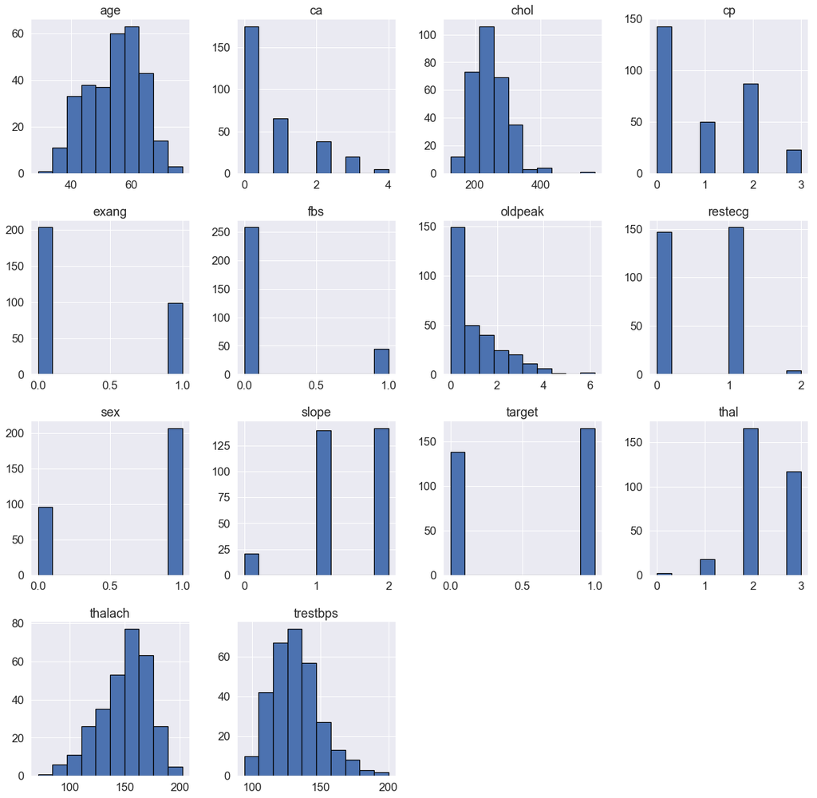

```python
sns.set(font_scale=1.5)
data.hist(edgecolor='black', linewidth=1.2, figsize=(20, 20));
```

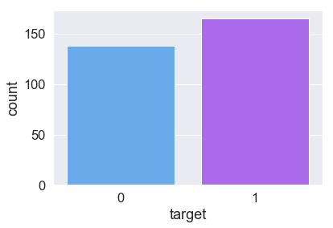

```python
sns.countplot(x='target',data=data, palette='cool')
```

```python
data['target'].value_counts()
```

```
1    165
0    138
Name: target, dtype: int64
```

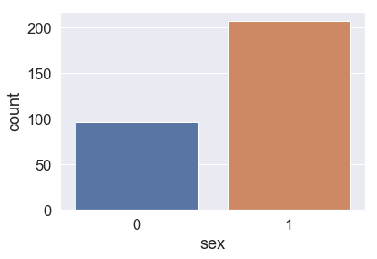

```python
sns.countplot(x='sex',data=data)
```

```python
data['sex'].value_counts()
```

```
1    207
0     96
Name: sex, dtype: int64
```

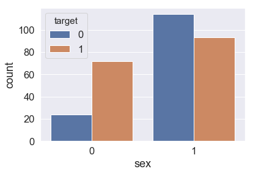

```python
sns.countplot(x='sex',hue='target',data=data)
```

```python
data.groupby('sex')['target'].value_counts(normalize=True)
```

```
sex  target
0    1         0.750000
     0         0.250000
1    0         0.550725
     1         0.449275
Name: target, dtype: float64
```

# Assignment-01: You need to check older age(>50) how many females and males are there and out of them how many had a heart attack

```python
older=data[data['age']>50]
```

```python
older['sex'].value_counts()
```

```
1    139
0     69
Name: sex, dtype: int64
```

```python
older.groupby('sex')['target'].value_counts(normalize=True)
```

```
sex  target
0    1         0.666667
     0         0.333333
1    0         0.618705
     1         0.381295
Name: target, dtype: float64
```

# Assignment-02: What is the probability of getting a heart attack of person greater than age 50 and had no cp ever and no fasting blood sugar?

```python
healthy=older[(older['cp']==0) & (older['fbs']==0)]
```

```python
healthy['target'].value_counts()
```

```
0    69
1    24
Name: target, dtype: int64
```

```python
healthy['target'].value_counts(normalize=True)
```

```
0    0.741935
1    0.258065
Name: target, dtype: float64
```

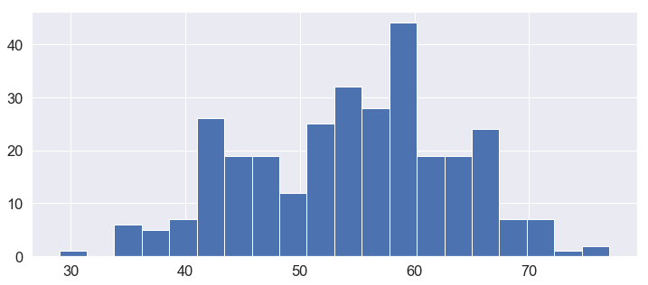

```python
plt.figure(figsize=(12, 5))
data.age.hist(bins=20)
```

```python
print(f"The most of the patients have a mean age of : {data.age.mean()}")
```

```
The most of the patients have a mean age of : 54.366336633663366
```

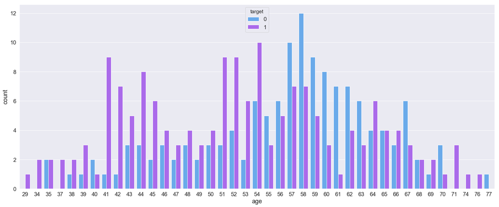

```python
plt.figure(figsize=(25,10))
sns.countplot(x='age',hue='target',data=data,palette='cool')
```

```python
# Copy the whole Dataset into another dataframe
df=data.copy()
```

```python
df.head()
```

|  | age | sex | cp | trestbps | chol | fbs | restecg | thalach | exang | oldpeak | slope | ca | thal | target |
| --- | --- | --- | --- | --- | --- | --- | --- | --- | --- | --- | --- | --- | --- | --- |
| 0 | 63 | 1 | 3 | 145 | 233 | 1 | 0 | 150 | 0 | 2.3 | 0 | 0 | 1 | 1 |
| 1 | 37 | 1 | 2 | 130 | 250 | 0 | 1 | 187 | 0 | 3.5 | 0 | 0 | 2 | 1 |
| 2 | 41 | 0 | 1 | 130 | 204 | 0 | 0 | 172 | 0 | 1.4 | 2 | 0 | 2 | 1 |
| 3 | 56 | 1 | 1 | 120 | 236 | 0 | 1 | 178 | 0 | 0.8 | 2 | 0 | 2 | 1 |
| 4 | 57 | 0 | 0 | 120 | 354 | 0 | 1 | 163 | 1 | 0.6 | 2 | 0 | 2 | 1 |

```python
df['target'].value_counts()
```

```
1    165
0    138
Name: target, dtype: int64
```

```python
import plotly
import plotly.express as px
import plotly.graph_objects as go
#plt.rcParams['figure.figsize']=17,8
import plotly.offline as pyo
from plotly.offline import init_notebook_mode,plot,iplot
```

```python
#------------COUNT-----------------------
def target_count():
    trace = go.Bar( x = df['target'].value_counts().values.tolist(),
                    y = ['Heart Disease','Healthy' ],
                    orientation = 'h',
                    text=df['target'].value_counts().values.tolist(),
                    textfont=dict(size=15),
                    textposition = 'auto',
                    opacity = 1,marker=dict(
                    color=['lightskyblue', 'gold'],
                    line=dict(color='#000000',width=1.5)))

    layout = dict(title =  'Count of target variable')

    fig = dict(data = [trace], layout=layout)
    iplot(fig)

#------------PERCENTAGE-------------------
def target_percent():
    trace = go.Pie(labels = ['Heart Disease','Healthy'], values = df['target'].value_counts(),
                   textfont=dict(size=15), opacity = 0.8,
                   marker=dict(colors=['lightskyblue', 'gold'],
                               line=dict(color='#000000', width=1.5)))


    layout = dict(title =  'Distribution of target variable')

    fig = dict(data = [trace], layout=layout)
    iplot(fig)
```

```python
target_count()
target_percent()
```

[interactive chart not shown]

```python
import plotly.figure_factory as ff
def plot_distribution(data_select, size_bin) :
    # 2 datasets
    tmp1 = df[data_select]
    tmp2 = df[data_select]
    hist_data = [tmp1, tmp2]

    group_labels = ['Heart Disease', 'Healthy']
    colors = ['gold', 'blue']

    fig = ff.create_distplot(hist_data, group_labels, colors = colors, show_hist = True, bin_size = size_bin, curve_type='kde')

    fig['layout'].update(title = data_select)

    iplot(fig, filename = 'Density plot')
```

```python
plot_distribution('chol', 10)
```

[interactive chart not shown]

```python
plot_distribution('thalach', 0)
```

[interactive chart not shown]

```python
categorical_values=['sex', 'cp', 'fbs', 'restecg', 'exang', 'slope', 'ca', 'thal', 'target']
```

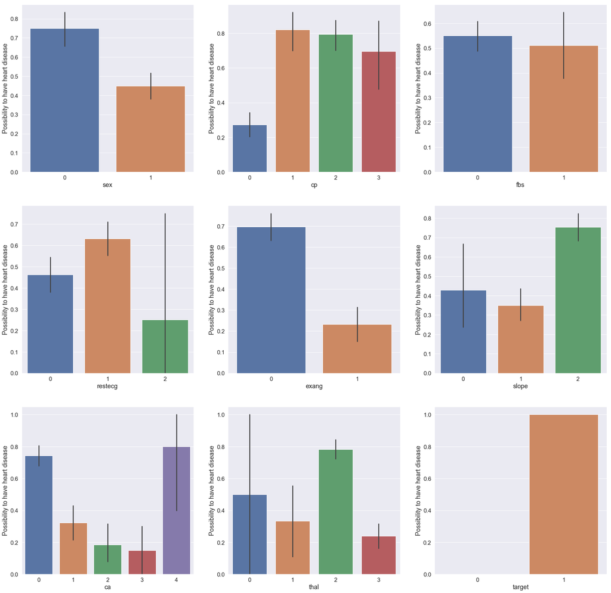

```python
plt.figure(figsize=(30, 30))
for i, column in enumerate(categorical_values, 1):
    plt.subplot(3, 3, i)
    sns.barplot(x=f"{column}", y='target', data=data)
    plt.ylabel('Possibility to have heart disease')
    plt.xlabel(f'{column}')
```

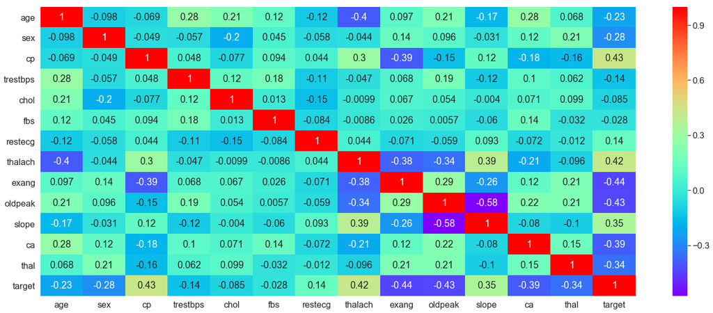

```python
plt.figure(figsize=(25,10))
sns.heatmap(df.corr(),annot=True,cmap='rainbow')
```

# Model Building

```python
from sklearn.metrics import accuracy_score
from sklearn.metrics import classification_report
from sklearn.metrics import confusion_matrix
from sklearn.model_selection import train_test_split
from sklearn.tree import DecisionTreeClassifier
```

```python
df.head()
```

|  | age | sex | cp | trestbps | chol | fbs | restecg | thalach | exang | oldpeak | slope | ca | thal | target |
| --- | --- | --- | --- | --- | --- | --- | --- | --- | --- | --- | --- | --- | --- | --- |
| 0 | 63 | 1 | 3 | 145 | 233 | 1 | 0 | 150 | 0 | 2.3 | 0 | 0 | 1 | 1 |
| 1 | 37 | 1 | 2 | 130 | 250 | 0 | 1 | 187 | 0 | 3.5 | 0 | 0 | 2 | 1 |
| 2 | 41 | 0 | 1 | 130 | 204 | 0 | 0 | 172 | 0 | 1.4 | 2 | 0 | 2 | 1 |
| 3 | 56 | 1 | 1 | 120 | 236 | 0 | 1 | 178 | 0 | 0.8 | 2 | 0 | 2 | 1 |
| 4 | 57 | 0 | 0 | 120 | 354 | 0 | 1 | 163 | 1 | 0.6 | 2 | 0 | 2 | 1 |

```python
X=df.drop('target',axis=1)
y=df['target']
```

```python
X_train, X_test, y_train, y_test = train_test_split(X, y, test_size=0.2)
```

```python
#Model
DT = DecisionTreeClassifier()

#fiting the model
DT.fit(X_train, y_train)

#prediction
y_pred = DT.predict(X_test)

DT_accuracy=accuracy_score(y_test,y_pred)*100
#Accuracy
print("Accuracy ",DT_accuracy)
```

```
Accuracy  77.04918032786885
```

```python
from sklearn.linear_model import LogisticRegression
#Model
LR = LogisticRegression()

#fiting the model
LR.fit(X_train, y_train)

#prediction
y_pred = LR.predict(X_test)

LR_accuracy=accuracy_score(y_test,y_pred)

#Accuracy
print("Accuracy ", LR_accuracy*100)
```

```
Accuracy  83.60655737704919
```

```python
from sklearn.model_selection import KFold
from sklearn.model_selection import cross_val_score
k_fold = KFold(n_splits=5, shuffle=True, random_state=20)
```

```python
cross_val_score_Decision = cross_val_score(DT, X, y, cv=k_fold, scoring="accuracy")
cross_val_score_Decision
```

```
array([0.75409836, 0.75409836, 0.80327869, 0.83333333, 0.73333333])
```

```python
cross_val_score_Decision.mean()
```

```
0.7756284153005464
```

```python
cross_val_score_logistic = cross_val_score(LR, X, y, cv=k_fold, scoring="accuracy")
cross_val_score_logistic
```

```
array([0.73770492, 0.78688525, 0.85245902, 0.9       , 0.78333333])
```

```python
cross_val_score_logistic.mean()
```

```
0.8120765027322404
```